# Risk Factor Analysis

## Outcome Variable

**Outcome Variable:** ever_wasted

## Predictor Variables

**Intervention Variable:** parity

**Adjustment Set:**

- arm
- W_mage
- meducyrs
- feducyrs
- hhwealth_quart
- W_mhtcm
- W_mwtkg
- W_mbmi
- vagbrth
- W_nrooms
- impsan
- delta_W_mage
- delta_meducyrs
- delta_feducyrs
- delta_hhwealth_quart
- delta_W_mhtcm
- delta_W_mwtkg
- delta_W_mbmi
- delta_vagbrth
- delta_W_nrooms
- delta_impsan

## Stratifying Variables

The analysis was stratified on these variable(s):

- agecat
- studyid
- country

## Data Summary

| agecat | studyid | country | parity | ever_wasted | n_cell | n |
| --- | --- | --- | --- | --- | --- | --- |
| 0-24 months | COHORTS | GUATEMALA | 1 | 0 | 162 | 1341 |
| 0-24 months | COHORTS | GUATEMALA | 1 | 1 | 46 | 1341 |
| 0-24 months | COHORTS | GUATEMALA | 2 | 0 | 132 | 1341 |
| 0-24 months | COHORTS | GUATEMALA | 2 | 1 | 55 | 1341 |
| 0-24 months | COHORTS | GUATEMALA | 3+ | 0 | 705 | 1341 |
| 0-24 months | COHORTS | GUATEMALA | 3+ | 1 | 241 | 1341 |
| 0-24 months | COHORTS | INDIA | 1 | 0 | 560 | 4624 |
| 0-24 months | COHORTS | INDIA | 1 | 1 | 250 | 4624 |
| 0-24 months | COHORTS | INDIA | 2 | 0 | 821 | 4624 |
| 0-24 months | COHORTS | INDIA | 2 | 1 | 363 | 4624 |
| 0-24 months | COHORTS | INDIA | 3+ | 0 | 1681 | 4624 |
| 0-24 months | COHORTS | INDIA | 3+ | 1 | 949 | 4624 |
| 0-24 months | COHORTS | PHILIPPINES | 1 | 0 | 394 | 3045 |
| 0-24 months | COHORTS | PHILIPPINES | 1 | 1 | 283 | 3045 |
| 0-24 months | COHORTS | PHILIPPINES | 2 | 0 | 424 | 3045 |
| 0-24 months | COHORTS | PHILIPPINES | 2 | 1 | 258 | 3045 |
| 0-24 months | COHORTS | PHILIPPINES | 3+ | 0 | 998 | 3045 |
| 0-24 months | COHORTS | PHILIPPINES | 3+ | 1 | 688 | 3045 |
| 0-24 months | GMS-Nepal | NEPAL | 1 | 0 | 89 | 686 |
| 0-24 months | GMS-Nepal | NEPAL | 1 | 1 | 114 | 686 |
| 0-24 months | GMS-Nepal | NEPAL | 2 | 0 | 78 | 686 |
| 0-24 months | GMS-Nepal | NEPAL | 2 | 1 | 102 | 686 |
| 0-24 months | GMS-Nepal | NEPAL | 3+ | 0 | 114 | 686 |
| 0-24 months | GMS-Nepal | NEPAL | 3+ | 1 | 189 | 686 |
| 0-24 months | JiVitA-3 | BANGLADESH | 1 | 0 | 7422 | 26956 |
| 0-24 months | JiVitA-3 | BANGLADESH | 1 | 1 | 2704 | 26956 |
| 0-24 months | JiVitA-3 | BANGLADESH | 2 | 0 | 6779 | 26956 |
| 0-24 months | JiVitA-3 | BANGLADESH | 2 | 1 | 2155 | 26956 |
| 0-24 months | JiVitA-3 | BANGLADESH | 3+ | 0 | 5800 | 26956 |
| 0-24 months | JiVitA-3 | BANGLADESH | 3+ | 1 | 2096 | 26956 |

[output cut: 168 more lines]

The following strata were considered:

- agecat: 0-24 months, studyid: COHORTS, country: GUATEMALA
- agecat: 0-24 months, studyid: COHORTS, country: INDIA
- agecat: 0-24 months, studyid: COHORTS, country: PHILIPPINES
- agecat: 0-24 months, studyid: GMS-Nepal, country: NEPAL
- agecat: 0-24 months, studyid: JiVitA-3, country: BANGLADESH
- agecat: 0-24 months, studyid: Keneba, country: GAMBIA
- agecat: 0-24 months, studyid: PROVIDE, country: BANGLADESH
- agecat: 0-24 months, studyid: SAS-CompFeed, country: INDIA
- agecat: 0-24 months, studyid: SAS-FoodSuppl, country: INDIA
- agecat: 0-24 months, studyid: TanzaniaChild2, country: TANZANIA, UNITED REPUBLIC OF
- agecat: 0-24 months, studyid: ZVITAMBO, country: ZIMBABWE
- agecat: 0-6 months, studyid: COHORTS, country: GUATEMALA
- agecat: 0-6 months, studyid: COHORTS, country: INDIA
- agecat: 0-6 months, studyid: COHORTS, country: PHILIPPINES
- agecat: 0-6 months, studyid: GMS-Nepal, country: NEPAL
- agecat: 0-6 months, studyid: JiVitA-3, country: BANGLADESH
- agecat: 0-6 months, studyid: Keneba, country: GAMBIA
- agecat: 0-6 months, studyid: PROVIDE, country: BANGLADESH
- agecat: 0-6 months, studyid: SAS-CompFeed, country: INDIA
- agecat: 0-6 months, studyid: SAS-FoodSuppl, country: INDIA
- agecat: 0-6 months, studyid: TanzaniaChild2, country: TANZANIA, UNITED REPUBLIC OF
- agecat: 0-6 months, studyid: ZVITAMBO, country: ZIMBABWE
- agecat: 6-24 months, studyid: COHORTS, country: GUATEMALA
- agecat: 6-24 months, studyid: COHORTS, country: INDIA
- agecat: 6-24 months, studyid: COHORTS, country: PHILIPPINES
- agecat: 6-24 months, studyid: GMS-Nepal, country: NEPAL
- agecat: 6-24 months, studyid: JiVitA-3, country: BANGLADESH
- agecat: 6-24 months, studyid: Keneba, country: GAMBIA
- agecat: 6-24 months, studyid: PROVIDE, country: BANGLADESH
- agecat: 6-24 months, studyid: SAS-CompFeed, country: INDIA
- agecat: 6-24 months, studyid: SAS-FoodSuppl, country: INDIA
- agecat: 6-24 months, studyid: TanzaniaChild2, country: TANZANIA, UNITED REPUBLIC OF
- agecat: 6-24 months, studyid: ZVITAMBO, country: ZIMBABWE

### Dropped Strata

Some strata were dropped due to rare outcomes:

- agecat: 6-24 months, studyid: SAS-FoodSuppl, country: INDIA

## Methods Detail

We're interested in the causal parameters $E[Y_a]$ for all values of $a \in \mathcal{A}$. These parameters represent the mean outcome if, possibly contrary to fact, we intervened to set all units to have $A=a$. Under the randomization and positivity assumptions, these are identified by the statistical parameters $\psi_a=E_W[E_{Y|A,W}(Y|A=a,W)]$. In addition, we're interested in the mean of $Y$, $E[Y]$ under no intervention (the observed mean). We will estimate these parameters by using SuperLearner to fit the relevant likelihood factors -- $E_{Y|A,W}(Y|A=a,W)$ and $p(A=a|W)$, and then updating our likelihood fit using a joint TMLE.

For unadjusted analyses ($W=\{\}$), initial likelihoods were estimated using Lrnr_glm to estimate the simple $E(Y|A)$ and Lrnr_mean to estimate $p(A)$. For adjusted analyses, a small library containing Lrnr_glmnet, Lrnr_xgboost, and Lrnr_mean was used.

Having estimated these parameters, we will then use the delta method to estimate relative risks and attributable risks relative to a prespecified baseline level of $A$.

# Results Detail

## Results Plots

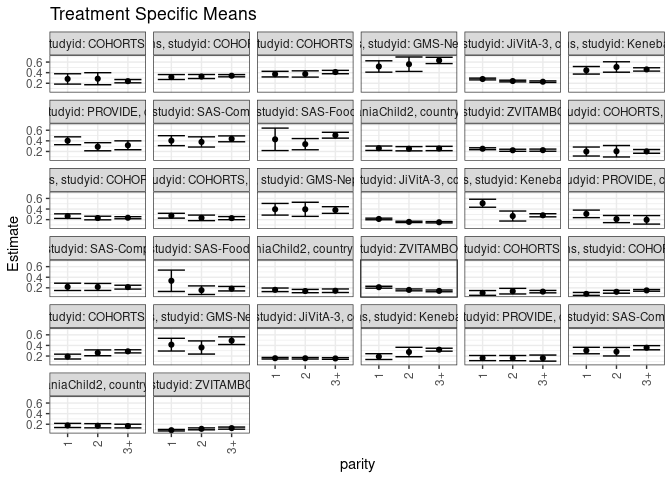

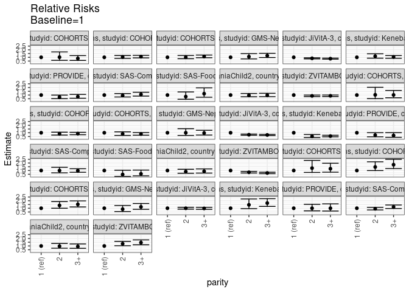

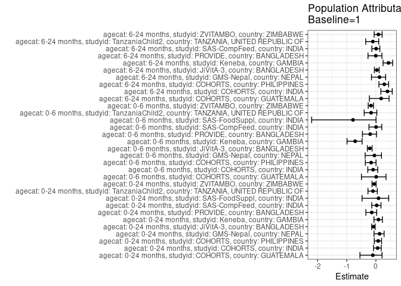

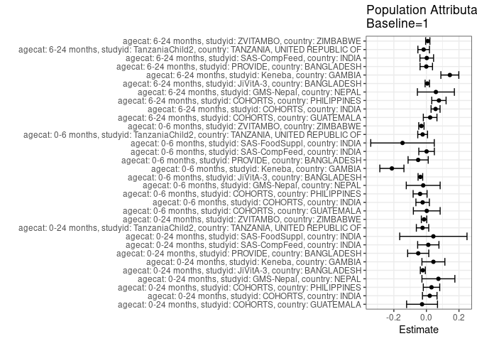

## Results Table

### Parameter: TSM

| agecat | studyid | country | intervention_level | baseline_level | estimate | ci_lower | ci_upper |
| --- | --- | --- | --- | --- | --- | --- | --- |
| 0-24 months | COHORTS | GUATEMALA | 1 | NA | 0.2817272 | 0.1842253 | 0.3792291 |
| 0-24 months | COHORTS | GUATEMALA | 2 | NA | 0.2858692 | 0.1721784 | 0.3995600 |
| 0-24 months | COHORTS | GUATEMALA | 3+ | NA | 0.2394712 | 0.2084713 | 0.2704711 |
| 0-24 months | COHORTS | INDIA | 1 | NA | 0.3173033 | 0.2707988 | 0.3638079 |
| 0-24 months | COHORTS | INDIA | 2 | NA | 0.3274238 | 0.2894032 | 0.3654444 |
| 0-24 months | COHORTS | INDIA | 3+ | NA | 0.3421841 | 0.3210444 | 0.3633238 |
| 0-24 months | COHORTS | PHILIPPINES | 1 | NA | 0.3722469 | 0.3193364 | 0.4251574 |
| 0-24 months | COHORTS | PHILIPPINES | 2 | NA | 0.3753072 | 0.3163714 | 0.4342430 |
| 0-24 months | COHORTS | PHILIPPINES | 3+ | NA | 0.4117426 | 0.3798674 | 0.4436178 |
| 0-24 months | GMS-Nepal | NEPAL | 1 | NA | 0.5166927 | 0.4093507 | 0.6240347 |
| 0-24 months | GMS-Nepal | NEPAL | 2 | NA | 0.5593409 | 0.4230510 | 0.6956308 |
| 0-24 months | GMS-Nepal | NEPAL | 3+ | NA | 0.6309573 | 0.5712839 | 0.6906306 |
| 0-24 months | JiVitA-3 | BANGLADESH | 1 | NA | 0.2799074 | 0.2631779 | 0.2966369 |
| 0-24 months | JiVitA-3 | BANGLADESH | 2 | NA | 0.2421533 | 0.2264253 | 0.2578813 |
| 0-24 months | JiVitA-3 | BANGLADESH | 3+ | NA | 0.2291389 | 0.2142200 | 0.2440578 |
| 0-24 months | Keneba | GAMBIA | 1 | NA | 0.4444559 | 0.3733779 | 0.5155339 |
| 0-24 months | Keneba | GAMBIA | 2 | NA | 0.5070129 | 0.4085944 | 0.6054314 |
| 0-24 months | Keneba | GAMBIA | 3+ | NA | 0.4612404 | 0.4298488 | 0.4926320 |
| 0-24 months | PROVIDE | BANGLADESH | 1 | NA | 0.4017169 | 0.3274316 | 0.4760022 |
| 0-24 months | PROVIDE | BANGLADESH | 2 | NA | 0.2888674 | 0.2123858 | 0.3653490 |
| 0-24 months | PROVIDE | BANGLADESH | 3+ | NA | 0.3165969 | 0.2325913 | 0.4006025 |
| 0-24 months | SAS-CompFeed | INDIA | 1 | NA | 0.4034414 | 0.3092059 | 0.4976768 |
| 0-24 months | SAS-CompFeed | INDIA | 2 | NA | 0.3800184 | 0.2838907 | 0.4761462 |
| 0-24 months | SAS-CompFeed | INDIA | 3+ | NA | 0.4380589 | 0.3825851 | 0.4935328 |
| 0-24 months | SAS-FoodSuppl | INDIA | 1 | NA | 0.4285714 | 0.2166616 | 0.6404813 |
| 0-24 months | SAS-FoodSuppl | INDIA | 2 | NA | 0.3376623 | 0.2319066 | 0.4434181 |
| 0-24 months | SAS-FoodSuppl | INDIA | 3+ | NA | 0.5062500 | 0.4514060 | 0.5610940 |
| 0-24 months | TanzaniaChild2 | TANZANIA, UNITED REPUBLIC OF | 1 | NA | 0.2604741 | 0.2184997 | 0.3024485 |
| 0-24 months | TanzaniaChild2 | TANZANIA, UNITED REPUBLIC OF | 2 | NA | 0.2515026 | 0.2112119 | 0.2917934 |
| 0-24 months | TanzaniaChild2 | TANZANIA, UNITED REPUBLIC OF | 3+ | NA | 0.2556391 | 0.2147815 | 0.2964967 |

[output cut: 66 more lines]

### Parameter: E(Y)

| agecat | studyid | country | intervention_level | baseline_level | estimate | ci_lower | ci_upper |
| --- | --- | --- | --- | --- | --- | --- | --- |
| 0-24 months | COHORTS | GUATEMALA | NA | NA | 0.2550336 | 0.2316956 | 0.2783715 |
| 0-24 months | COHORTS | INDIA | NA | NA | 0.3378028 | 0.3241691 | 0.3514364 |
| 0-24 months | COHORTS | PHILIPPINES | NA | NA | 0.4036125 | 0.3861835 | 0.4210415 |
| 0-24 months | GMS-Nepal | NEPAL | NA | NA | 0.5903790 | 0.5535526 | 0.6272054 |
| 0-24 months | JiVitA-3 | BANGLADESH | NA | NA | 0.2580131 | 0.2515484 | 0.2644777 |
| 0-24 months | Keneba | GAMBIA | NA | NA | 0.4874372 | 0.4654705 | 0.5094038 |
| 0-24 months | PROVIDE | BANGLADESH | NA | NA | 0.3514286 | 0.3160364 | 0.3868207 |
| 0-24 months | SAS-CompFeed | INDIA | NA | NA | 0.4150694 | 0.3581204 | 0.4720184 |
| 0-24 months | SAS-FoodSuppl | INDIA | NA | NA | 0.4712919 | 0.4233811 | 0.5192026 |
| 0-24 months | TanzaniaChild2 | TANZANIA, UNITED REPUBLIC OF | NA | NA | 0.2367416 | 0.2195770 | 0.2539062 |
| 0-24 months | ZVITAMBO | ZIMBABWE | NA | NA | 0.2367157 | 0.2296604 | 0.2437709 |
| 0-6 months | COHORTS | GUATEMALA | NA | NA | 0.2003763 | 0.1763021 | 0.2244505 |
| 0-6 months | COHORTS | INDIA | NA | NA | 0.2434743 | 0.2308547 | 0.2560940 |
| 0-6 months | COHORTS | PHILIPPINES | NA | NA | 0.2355453 | 0.2204685 | 0.2506222 |
| 0-6 months | GMS-Nepal | NEPAL | NA | NA | 0.3760933 | 0.3398180 | 0.4123685 |
| 0-6 months | JiVitA-3 | BANGLADESH | NA | NA | 0.1761793 | 0.1705546 | 0.1818041 |
| 0-6 months | Keneba | GAMBIA | NA | NA | 0.2976769 | 0.2768415 | 0.3185124 |
| 0-6 months | PROVIDE | BANGLADESH | NA | NA | 0.2585714 | 0.2261125 | 0.2910304 |
| 0-6 months | SAS-CompFeed | INDIA | NA | NA | 0.2199336 | 0.1753445 | 0.2645227 |
| 0-6 months | SAS-FoodSuppl | INDIA | NA | NA | 0.1866029 | 0.1492099 | 0.2239959 |
| 0-6 months | TanzaniaChild2 | TANZANIA, UNITED REPUBLIC OF | NA | NA | 0.1395842 | 0.1255905 | 0.1535779 |
| 0-6 months | ZVITAMBO | ZIMBABWE | NA | NA | 0.1811291 | 0.1747154 | 0.1875428 |
| 6-24 months | COHORTS | GUATEMALA | NA | NA | 0.1269580 | 0.1082147 | 0.1457012 |
| 6-24 months | COHORTS | INDIA | NA | NA | 0.1419682 | 0.1315821 | 0.1523542 |
| 6-24 months | COHORTS | PHILIPPINES | NA | NA | 0.2666429 | 0.2502871 | 0.2829988 |
| 6-24 months | GMS-Nepal | NEPAL | NA | NA | 0.4728814 | 0.4325613 | 0.5132014 |
| 6-24 months | JiVitA-3 | BANGLADESH | NA | NA | 0.1640074 | 0.1578946 | 0.1701202 |
| 6-24 months | Keneba | GAMBIA | NA | NA | 0.3336798 | 0.3126050 | 0.3547547 |
| 6-24 months | PROVIDE | BANGLADESH | NA | NA | 0.1609756 | 0.1319065 | 0.1900447 |
| 6-24 months | SAS-CompFeed | INDIA | NA | NA | 0.3059755 | 0.2638053 | 0.3481458 |
| 6-24 months | TanzaniaChild2 | TANZANIA, UNITED REPUBLIC OF | NA | NA | 0.1600403 | 0.1439152 | 0.1761654 |
| 6-24 months | ZVITAMBO | ZIMBABWE | NA | NA | 0.0958942 | 0.0903444 | 0.1014441 |

### Parameter: RR

| agecat | studyid | country | intervention_level | baseline_level | estimate | ci_lower | ci_upper |
| --- | --- | --- | --- | --- | --- | --- | --- |
| 0-24 months | COHORTS | GUATEMALA | 1 | 1 | 1.0000000 | 1.0000000 | 1.0000000 |
| 0-24 months | COHORTS | GUATEMALA | 2 | 1 | 1.0147023 | 0.5990264 | 1.7188237 |
| 0-24 months | COHORTS | GUATEMALA | 3+ | 1 | 0.8500111 | 0.5874486 | 1.2299270 |
| 0-24 months | COHORTS | INDIA | 1 | 1 | 1.0000000 | 1.0000000 | 1.0000000 |
| 0-24 months | COHORTS | INDIA | 2 | 1 | 1.0318951 | 0.8559749 | 1.2439706 |
| 0-24 months | COHORTS | INDIA | 3+ | 1 | 1.0784131 | 0.9199340 | 1.2641939 |
| 0-24 months | COHORTS | PHILIPPINES | 1 | 1 | 1.0000000 | 1.0000000 | 1.0000000 |
| 0-24 months | COHORTS | PHILIPPINES | 2 | 1 | 1.0082210 | 0.8158496 | 1.2459522 |
| 0-24 months | COHORTS | PHILIPPINES | 3+ | 1 | 1.1061008 | 0.9408235 | 1.3004129 |
| 0-24 months | GMS-Nepal | NEPAL | 1 | 1 | 1.0000000 | 1.0000000 | 1.0000000 |
| 0-24 months | GMS-Nepal | NEPAL | 2 | 1 | 1.0825407 | 0.7857499 | 1.4914344 |
| 0-24 months | GMS-Nepal | NEPAL | 3+ | 1 | 1.2211460 | 0.9719295 | 1.5342652 |
| 0-24 months | JiVitA-3 | BANGLADESH | 1 | 1 | 1.0000000 | 1.0000000 | 1.0000000 |
| 0-24 months | JiVitA-3 | BANGLADESH | 2 | 1 | 0.8651193 | 0.7955123 | 0.9408169 |
| 0-24 months | JiVitA-3 | BANGLADESH | 3+ | 1 | 0.8186240 | 0.7500289 | 0.8934925 |
| 0-24 months | Keneba | GAMBIA | 1 | 1 | 1.0000000 | 1.0000000 | 1.0000000 |
| 0-24 months | Keneba | GAMBIA | 2 | 1 | 1.1407496 | 0.8870383 | 1.4670276 |
| 0-24 months | Keneba | GAMBIA | 3+ | 1 | 1.0377642 | 0.8722163 | 1.2347334 |
| 0-24 months | PROVIDE | BANGLADESH | 1 | 1 | 1.0000000 | 1.0000000 | 1.0000000 |
| 0-24 months | PROVIDE | BANGLADESH | 2 | 1 | 0.7190820 | 0.5211092 | 0.9922659 |
| 0-24 months | PROVIDE | BANGLADESH | 3+ | 1 | 0.7881094 | 0.5706947 | 1.0883514 |
| 0-24 months | SAS-CompFeed | INDIA | 1 | 1 | 1.0000000 | 1.0000000 | 1.0000000 |
| 0-24 months | SAS-CompFeed | INDIA | 2 | 1 | 0.9419421 | 0.7406313 | 1.1979712 |
| 0-24 months | SAS-CompFeed | INDIA | 3+ | 1 | 1.0858057 | 0.8594407 | 1.3717922 |
| 0-24 months | SAS-FoodSuppl | INDIA | 1 | 1 | 1.0000000 | 1.0000000 | 1.0000000 |
| 0-24 months | SAS-FoodSuppl | INDIA | 2 | 1 | 0.7878788 | 0.4387984 | 1.4146657 |
| 0-24 months | SAS-FoodSuppl | INDIA | 3+ | 1 | 1.1812500 | 0.7120467 | 1.9596350 |
| 0-24 months | TanzaniaChild2 | TANZANIA, UNITED REPUBLIC OF | 1 | 1 | 1.0000000 | 1.0000000 | 1.0000000 |
| 0-24 months | TanzaniaChild2 | TANZANIA, UNITED REPUBLIC OF | 2 | 1 | 0.9655572 | 0.7694778 | 1.2116019 |
| 0-24 months | TanzaniaChild2 | TANZANIA, UNITED REPUBLIC OF | 3+ | 1 | 0.9814378 | 0.7820465 | 1.2316660 |

[output cut: 66 more lines]

### Parameter: PAR

| agecat | studyid | country | intervention_level | baseline_level | estimate | ci_lower | ci_upper |
| --- | --- | --- | --- | --- | --- | --- | --- |
| 0-24 months | COHORTS | GUATEMALA | 1 | NA | -0.0266936 | -0.1215716 | 0.0681844 |
| 0-24 months | COHORTS | INDIA | 1 | NA | 0.0204994 | -0.0242144 | 0.0652133 |
| 0-24 months | COHORTS | PHILIPPINES | 1 | NA | 0.0313656 | -0.0191184 | 0.0818495 |
| 0-24 months | GMS-Nepal | NEPAL | 1 | NA | 0.0736863 | -0.0274143 | 0.1747869 |
| 0-24 months | JiVitA-3 | BANGLADESH | 1 | NA | -0.0218944 | -0.0372540 | -0.0065347 |
| 0-24 months | Keneba | GAMBIA | 1 | NA | 0.0429813 | -0.0274452 | 0.1134079 |
| 0-24 months | PROVIDE | BANGLADESH | 1 | NA | -0.0502884 | -0.1151484 | 0.0145717 |
| 0-24 months | SAS-CompFeed | INDIA | 1 | NA | 0.0116280 | -0.0536929 | 0.0769489 |
| 0-24 months | SAS-FoodSuppl | INDIA | 1 | NA | 0.0427204 | -0.1638931 | 0.2493340 |
| 0-24 months | TanzaniaChild2 | TANZANIA, UNITED REPUBLIC OF | 1 | NA | -0.0237325 | -0.0617344 | 0.0142695 |
| 0-24 months | ZVITAMBO | ZIMBABWE | 1 | NA | -0.0144289 | -0.0310724 | 0.0022146 |
| 0-6 months | COHORTS | GUATEMALA | 1 | NA | 0.0021703 | -0.0800291 | 0.0843697 |
| 0-6 months | COHORTS | INDIA | 1 | NA | -0.0230880 | -0.0644189 | 0.0182429 |
| 0-6 months | COHORTS | PHILIPPINES | 1 | NA | -0.0386891 | -0.0814918 | 0.0041136 |
| 0-6 months | GMS-Nepal | NEPAL | 1 | NA | -0.0196445 | -0.1236319 | 0.0843430 |
| 0-6 months | JiVitA-3 | BANGLADESH | 1 | NA | -0.0369819 | -0.0511403 | -0.0228234 |
| 0-6 months | Keneba | GAMBIA | 1 | NA | -0.2120324 | -0.2860653 | -0.1379996 |
| 0-6 months | PROVIDE | BANGLADESH | 1 | NA | -0.0506930 | -0.1125259 | 0.0111399 |
| 0-6 months | SAS-CompFeed | INDIA | 1 | NA | 0.0011278 | -0.0465953 | 0.0488510 |
| 0-6 months | SAS-FoodSuppl | INDIA | 1 | NA | -0.1467305 | -0.3417992 | 0.0483382 |
| 0-6 months | TanzaniaChild2 | TANZANIA, UNITED REPUBLIC OF | 1 | NA | -0.0230440 | -0.0530842 | 0.0069962 |
| 0-6 months | ZVITAMBO | ZIMBABWE | 1 | NA | -0.0308563 | -0.0471382 | -0.0145745 |
| 6-24 months | COHORTS | GUATEMALA | 1 | NA | 0.0229301 | -0.0189343 | 0.0647946 |
| 6-24 months | COHORTS | INDIA | 1 | NA | 0.0562747 | 0.0286948 | 0.0838547 |
| 6-24 months | COHORTS | PHILIPPINES | 1 | NA | 0.0768553 | 0.0328848 | 0.1208258 |
| 6-24 months | GMS-Nepal | NEPAL | 1 | NA | 0.0582538 | -0.0552906 | 0.1717982 |
| 6-24 months | JiVitA-3 | BANGLADESH | 1 | NA | 0.0054172 | -0.0080249 | 0.0188592 |
| 6-24 months | Keneba | GAMBIA | 1 | NA | 0.1440287 | 0.0889385 | 0.1991189 |
| 6-24 months | PROVIDE | BANGLADESH | 1 | NA | -0.0006771 | -0.0388900 | 0.0375357 |
| 6-24 months | SAS-CompFeed | INDIA | 1 | NA | 0.0021571 | -0.0397119 | 0.0440261 |
| 6-24 months | TanzaniaChild2 | TANZANIA, UNITED REPUBLIC OF | 1 | NA | -0.0168001 | -0.0523398 | 0.0187395 |
| 6-24 months | ZVITAMBO | ZIMBABWE | 1 | NA | 0.0082884 | -0.0047736 | 0.0213503 |

### Parameter: PAF

| agecat | studyid | country | intervention_level | baseline_level | estimate | ci_lower | ci_upper |
| --- | --- | --- | --- | --- | --- | --- | --- |
| 0-24 months | COHORTS | GUATEMALA | 1 | NA | -0.1046670 | -0.5472919 | 0.2113387 |
| 0-24 months | COHORTS | INDIA | 1 | NA | 0.0606846 | -0.0814366 | 0.1841283 |
| 0-24 months | COHORTS | PHILIPPINES | 1 | NA | 0.0777121 | -0.0561828 | 0.1946327 |
| 0-24 months | GMS-Nepal | NEPAL | 1 | NA | 0.1248119 | -0.0644823 | 0.2804443 |
| 0-24 months | JiVitA-3 | BANGLADESH | 1 | NA | -0.0848575 | -0.1460675 | -0.0269167 |
| 0-24 months | Keneba | GAMBIA | 1 | NA | 0.0881781 | -0.0678576 | 0.2214139 |
| 0-24 months | PROVIDE | BANGLADESH | 1 | NA | -0.1430969 | -0.3438363 | 0.0276564 |
| 0-24 months | SAS-CompFeed | INDIA | 1 | NA | 0.0280147 | -0.1437010 | 0.1739489 |
| 0-24 months | SAS-FoodSuppl | INDIA | 1 | NA | 0.0906454 | -0.4727690 | 0.4385231 |
| 0-24 months | TanzaniaChild2 | TANZANIA, UNITED REPUBLIC OF | 1 | NA | -0.1002463 | -0.2731091 | 0.0491453 |
| 0-24 months | ZVITAMBO | ZIMBABWE | 1 | NA | -0.0609547 | -0.1336739 | 0.0071000 |
| 0-6 months | COHORTS | GUATEMALA | 1 | NA | 0.0108310 | -0.4974823 | 0.3465997 |
| 0-6 months | COHORTS | INDIA | 1 | NA | -0.0948272 | -0.2785091 | 0.0624653 |
| 0-6 months | COHORTS | PHILIPPINES | 1 | NA | -0.1642532 | -0.3610991 | 0.0041243 |
| 0-6 months | GMS-Nepal | NEPAL | 1 | NA | -0.0522329 | -0.3685032 | 0.1909451 |
| 0-6 months | JiVitA-3 | BANGLADESH | 1 | NA | -0.2099104 | -0.2933351 | -0.1318669 |
| 0-6 months | Keneba | GAMBIA | 1 | NA | -0.7122904 | -0.9905683 | -0.4729153 |
| 0-6 months | PROVIDE | BANGLADESH | 1 | NA | -0.1960503 | -0.4612203 | 0.0209989 |
| 0-6 months | SAS-CompFeed | INDIA | 1 | NA | 0.0051281 | -0.2374890 | 0.2001787 |
| 0-6 months | SAS-FoodSuppl | INDIA | 1 | NA | -0.7863248 | -2.2032501 | 0.0038379 |
| 0-6 months | TanzaniaChild2 | TANZANIA, UNITED REPUBLIC OF | 1 | NA | -0.1650905 | -0.4013953 | 0.0313683 |
| 0-6 months | ZVITAMBO | ZIMBABWE | 1 | NA | -0.1703556 | -0.2638280 | -0.0837964 |
| 6-24 months | COHORTS | GUATEMALA | 1 | NA | 0.1806119 | -0.2242685 | 0.4515934 |
| 6-24 months | COHORTS | INDIA | 1 | NA | 0.3963897 | 0.1701087 | 0.5609722 |
| 6-24 months | COHORTS | PHILIPPINES | 1 | NA | 0.2882331 | 0.1034791 | 0.4349132 |
| 6-24 months | GMS-Nepal | NEPAL | 1 | NA | 0.1231891 | -0.1530805 | 0.3332665 |
| 6-24 months | JiVitA-3 | BANGLADESH | 1 | NA | 0.0330300 | -0.0524831 | 0.1115953 |
| 6-24 months | Keneba | GAMBIA | 1 | NA | 0.4316375 | 0.2449478 | 0.5721674 |
| 6-24 months | PROVIDE | BANGLADESH | 1 | NA | -0.0042064 | -0.2719838 | 0.2071986 |
| 6-24 months | SAS-CompFeed | INDIA | 1 | NA | 0.0070498 | -0.1397218 | 0.1349204 |
| 6-24 months | TanzaniaChild2 | TANZANIA, UNITED REPUBLIC OF | 1 | NA | -0.1049745 | -0.3509933 | 0.0962437 |
| 6-24 months | ZVITAMBO | ZIMBABWE | 1 | NA | 0.0864323 | -0.0602788 | 0.2128429 |